# Lista de Exercícios 6

Métodos Numéricos

Antonio Carlos da Silva Júnior

23/04/2023

# Questão 1

Considere o método regula-falsi para a solução de uma equação não linear. Forneça uma implementação em R deste método e use sua implementação para resolver a seguinte equação não linear:

$$D(\theta) = 2n \left[ \log
\left(\frac{\hat{\theta}}{\theta} \right) + \bar{y}(\theta -
\hat{\theta})\right] \leq 3.84$$

```r
## Método Regula Falsi
regula_falsi <- function(fx, a, b, tol = 1e-04, max_iter = 100) {
  fa <- fx(a)
  fb <- fx(b)

  if(fa*fb > 0) {
    stop("Solução não está no intervalo")
  }

  solucao <- c()
  sol <- (a*fx(b) - b*fx(a))/(fx(b) - fx(a))
  solucao[1] <- sol
  limites <- matrix(NA, ncol = 2, nrow = max_iter)

  for(i in 1:max_iter) {
    test <- fx(a)*fx(sol)

    if(test < 0) {
      b = sol
      solucao[i+1] <- (a*fx(b) - b*fx(a))/(fx(b) - fx(a))
    }

    if(test > 0) {
      a = sol
      solucao[i+1] <- sol <- (a*fx(b) - b*fx(a))/(fx(b) - fx(a))
    }

    if( abs(solucao[i+1] - solucao[i]) < tol) {
      break
    }

    sol = solucao[i+1]
    limites[i,] <- c(a,b)
  }
  out <- list("Tentativas" = solucao, "Limites" = limites, "Raiz" = sol)

  return(out)
}


## Implementando a função
ftheta <- function(theta){
  dd <- 2*length(y)*(log(theta.hat/theta) + mean(y)*(theta - theta.hat))
  return(dd - 3.84)
}


## Resolvendo numericamente
set.seed(123)
y <- rexp(20, rate = 1)
theta.hat <- 1/mean(y)
Ic_min <- regula_falsi(fx = ftheta, a = 0.000001, b = theta.hat)
Ic_max <- regula_falsi(fx = ftheta, a = theta.hat, b = 3)
c(Ic_min$Raiz, Ic_max$Raiz) ## Solução aproximada
```

```
## [1] 0.800975 1.854546
```

# Questão 2

Use o método de Newton para resolver o seguinte sistema de equações não lineares:

$$y = cos(x) \\
x = sen(y)$$

```r
newton <- function(fx, jacobian, x1, tol = 1e-04, max_iter = 10) {
  solucao <- matrix(NA, ncol = length(x1), nrow = max_iter)
  solucao[1,] <- x1
  for(i in 1:max_iter) {
    J <- jacobian(solucao[i,])
    grad <- fx(solucao[i,])
    solucao[i+1,] = solucao[i,] - solve(J, grad)
    if( sum(abs(solucao[i+1,] - solucao[i,])) < tol) break
  }
  return(solucao)
}

## Sistema a ser resolvido
fx <- function(x) c(cos(x[1]), sin(x[2]))

## Jacobiano
Jacobian <- function(x) matrix(c(-sin(x[1]), 0, 0, 1 / cos(x[2])), ncol = 2, byrow = TRUE)

sol <- newton(fx = fx, jacobian = Jacobian, x1 = c(1,1))
sol <- sol[!rowSums(is.na(sol)),]

# Solução:
c(tail(sol,1)[1], tail(sol,1)[2])
```

```
## [1] 1.570796 0.000000
```

# Questão 3

Implemente o método quasi-Newton BFGS. Use a sua implementação para otimizar a seguinte função perda:

$$L(y, \mu) = \sum_{i=1}^n
\log(\cosh(\mu_i - y_i))$$
Considere o seguinte código para gerar $y_i$. O parâmetro deve ser especificado como uma reta $\mu_i = \beta0 + \beta1 x_i$.

```r
set.seed(123)
x1 <- rnorm(100)
mu <- 5 + 3*x1
y <- rt(n = 100, df = 3) + mu
```

Note que você deverá otimizar os parâmetros $\beta_0$ e $\beta_1$ que na simulação foram fixados em $\beta_0 = 5$ e $\beta_1 = 3$.

```r
# Definindo a função perda:
cost_function <- function(beta){
  mu <- beta[1] + beta[2]*x1
  L <- sum(log(cosh(mu - y)))
  return(L)
}

# Implementação do BFGS
# Fonte: http://leg.ufpr.br/~wagner/TMCD/
BFGS <- function(inicial, funcao, gradiente = NULL, alpha, Hi = NULL, tol = 1e-04, max_iter = 150) {
  if(is.null(gradiente)) {
    gradiente <- function(ponto, ...) {
      numDeriv::grad(func = funcao, x = ponto, method = "simple", ...)
    }
  }
  ## Cria uma função para encontrar o alpha otimo a cada iteração
  fc <- function(alpha, xk, funcao, gradiente, ...) {
    xk1 <- xk - alpha*gradiente(ponto = xk, ...)
    out <- funcao(xk1, ...)
    return(out)
  }
  # Forma vetorizada para o grid search
  fc_vec <- Vectorize(fc, "alpha")
  ## Função para encontrar o alpha
  get_alpha <- function(xk, strategy = "golden_search", interval = c(0,1),
                        prec = 0.01, ...) {
    if(strategy == "grid_search") {
      gride <- seq(interval[1], interval[2], by = prec)
      fc_value <- fc_vec(alpha = gride, xk = xk, funcao = funcao, gradiente = gradiente, ...)
      alpha_otimo <- gride[which.min(fc_value)]
    }
    if(strategy == "golden_search") {
      out <- optimize(f = fc, interval = interval, xk = xk, funcao = funcao,
                      gradiente = gradiente, ...)
      alpha_otimo <- out$minimum
    }
    return(alpha_otimo)
  }
  if(is.null(Hi)) {Hi <- diag(1, nrow = length(inicial))}
  solucao <- matrix(NA, ncol = length(inicial), nrow = max_iter)
  solucao[1,] <- inicial
  alpha <- c()
  for(i in 1:c(max_iter-1)) {
    grad <- gradiente(solucao[i,])
    alpha[i] <- get_alpha(xk = solucao[i,])
    solucao[c(i+1),] = solucao[i,] - as.numeric(alpha[i]*Hi%*%grad)
    deltai <- solucao[c(i+1),] - solucao[i,]
    gammai <- gradiente(solucao[c(i+1),]) - gradiente(solucao[i,])
    #Bi <- Bi + (gammai%*%t(gammai))/as.numeric(t(gammai)%*%deltai) -
    #  (Bi%*%deltai%*%t(deltai)%*%t(Bi))/as.numeric(t(deltai)%*%Bi%*%deltai)
    term1 <- as.numeric((t(deltai)%*%gammai + t(gammai)%*%Hi%*%gammai))
    Hi <- Hi + term1*(deltai%*%t(deltai))/as.numeric((t(deltai)%*%gammai)^2) -
      (Hi%*%gammai%*%t(deltai) + deltai%*%t(gammai)%*%Hi)/ as.numeric(t(deltai)%*%gammai)
    if( sum(abs(solucao[c(i+1),] - solucao[i,])) < tol) break
  }
  out <- list("Solução" = solucao[c(i+1),], "Iterações" = solucao)
  return(out)
}

# Otimizando usando a função optim():
result <- optim(c(0,0), cost_function)
beta0_optim <- result$par[1]
beta1_optim <- result$par[2]
c(beta0_optim, beta1_optim)
```

```
## [1] 4.982821 2.771580
```

```r
# Otimizando usando a função BFGS():
result <- BFGS(c(0, 0), cost_function)
beta0_bfgs <- result$Solução[1]
beta1_bfgs <- result$Solução[2]
c(beta0_bfgs, beta1_bfgs)
```

```
## [1] 5.055671 2.784631
```

# Questão 4

```r
# Criando a função logística, considerando:
# par[1] = beta
# par[2] = beta_0
# par[3] = L
f_log <- function(par, dias) {
  return(par[3] / (1 + exp(-par[1]*(dias - par[2]))))
}

# Criando a função perda quadrática:
f_perda <- function(y, mu) {
  return(sum((y - mu)^2))
}

# Criando a função objetivo:
f_obj <- function(par, y, dias) {
  mu <- f_log(par, dias)
  SQ <- f_perda(y, mu)
  return(SQ)
}

# Lendo os dados:
df <- read.csv("youtube.txt", sep = "")

# Selecionando um dos canais:
df <- df %>% filter(CANAL == unique(df$CANAL)[1])

# Calculando o número acumulado de inscritos:
df$cum_inscritos <- cumsum(df$INSCRITOS)/100000

head(df)
```

```
##   DIAS VIEWS INSCRITOS         CANAL cum_inscritos
## 1    1  5200        66 inventonahora       0.00066
## 2    2  4600        89 inventonahora       0.00155
## 3    3  5200       103 inventonahora       0.00258
## 4    4  4400        87 inventonahora       0.00345
## 5    5  5100       102 inventonahora       0.00447
## 6    6  6200        93 inventonahora       0.00540
```

```r
str(df)
```

```
## 'data.frame':    850 obs. of  5 variables:
##  $ DIAS         : int  1 2 3 4 5 6 7 8 9 10 ...
##  $ VIEWS        : int  5200 4600 5200 4400 5100 6200 4800 4500 3700 3700 ...
##  $ INSCRITOS    : int  66 89 103 87 102 93 61 74 53 70 ...
##  $ CANAL        : chr  "inventonahora" "inventonahora" "inventonahora" "inventonahora" ...
##  $ cum_inscritos: num  0.00066 0.00155 0.00258 0.00345 0.00447 0.0054 0.00601 0.00675 0.00728 0.00798 ...
```

```r
summary(df)
```

```
##       DIAS           VIEWS          INSCRITOS          CANAL
##  Min.   :  1.0   Min.   :  3700   Min.   :   33.0   Length:850
##  1st Qu.:213.2   1st Qu.: 31000   1st Qu.:  548.2   Class :character
##  Median :425.5   Median :102500   Median : 2489.0   Mode  :character
##  Mean   :425.5   Mean   :109450   Mean   : 2494.5
##  3rd Qu.:637.8   3rd Qu.:158000   3rd Qu.: 3839.8
##  Max.   :850.0   Max.   :697000   Max.   :14611.0
##  cum_inscritos
##  Min.   : 0.00066
##  1st Qu.: 0.67368
##  Median : 4.53974
##  Mean   : 6.82862
##  3rd Qu.:11.94170
##  Max.   :21.20289
```

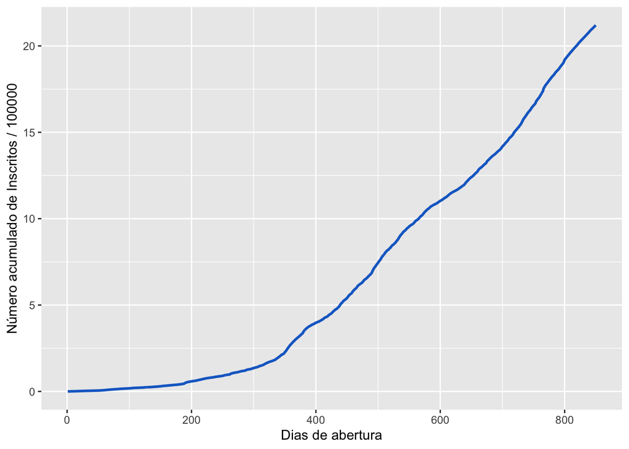

```r
# Plotando o número acumulado de inscritos por dia:
df %>%
  ggplot(aes(x=DIAS, y=cum_inscritos)) +
  geom_line(aes(y = cum_inscritos), color = "#166bcc", size = 1) +
  labs(x = "Dias de abertura", y = "Número acumulado de Inscritos / 100000")
```

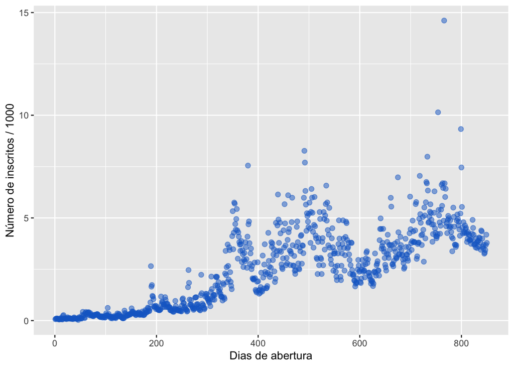

```r
# Plotando o número de inscritos por dia:
df %>%
  ggplot(aes(x = DIAS, y = INSCRITOS)) +
  geom_point(aes(y = INSCRITOS/1000), color = "#166bcc", alpha = 0.5, size = 2) +
  labs(x = "Dias de abertura", y = "Número de inscritos / 1000")
```

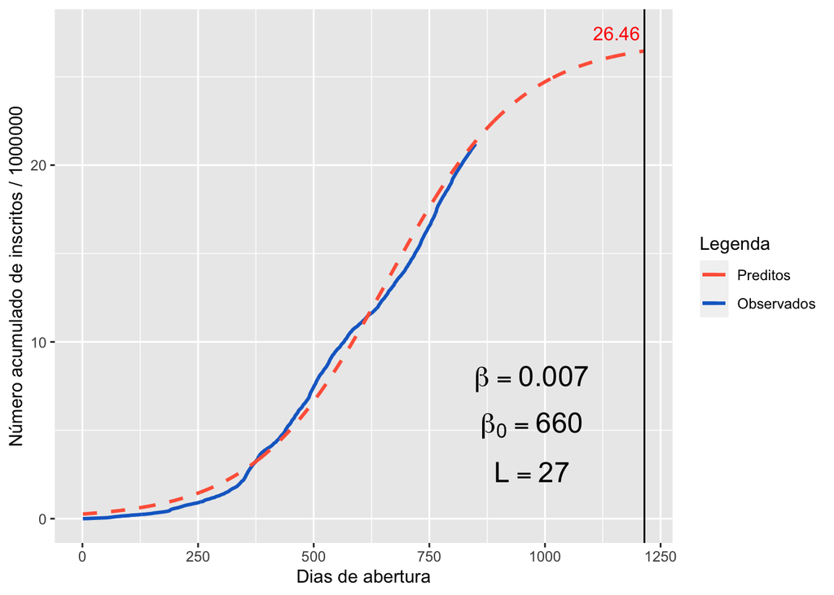

```r
# Preparando um data frame com o número total de dias:
days_pred = 365
df_pred <- data.frame(
  DIAS = c(df$DIAS, (max(df$DIAS)+1):(max(df$DIAS)+days_pred)),
  VIEWS = c(df$VIEWS, rep(NA, days_pred)),
  INSCRITOS = c(df$INSCRITOS, rep(NA, days_pred)),
  cum_inscritos = c(df$cum_inscritos, rep(NA, days_pred))
)

# Chute inicial (parâmetros escolhidos variando manualmente até encontrar uma curva aparentemente boa)
par_adj <- c(0.007, 660, 27)
df_pred$adj <- f_log(par = par_adj, dias = df_pred$DIAS)

df_pred %>%
  ggplot(aes(x = DIAS)) +
  geom_line(aes(y = cum_inscritos, color = "Observados"), size = 1) +
  geom_line(aes(y = adj, color = "Preditos"), linetype = "dashed", size = 1) +
  scale_color_manual(name = "Legenda", values = c("Preditos" = "tomato", "Observados" = "#166bcc")) +
  labs(x = "Dias de abertura", y = "Número acumulado de inscritos / 1000000") +
  geom_vline(xintercept = max(df_pred$DIAS), linetype = "solid", color = "black") +
  annotate("text", x = max(df_pred$DIAS)-60, y = max(df_pred$adj)+1, label = round(max(df_pred$adj),2), size = 4, color = "red") +
  annotate("text", x = max(df_pred$DIAS)*0.8, y = max(df_pred$adj)*0.1, label = paste0("L==",par_adj[3]), size = 6, parse = T) +
  annotate("text", x = max(df_pred$DIAS)*0.8, y = max(df_pred$adj)*0.2, label = paste0("beta[0]==",par_adj[2]), size = 6, parse = T) +
  annotate("text", x = max(df_pred$DIAS)*0.8, y = max(df_pred$adj)*0.3, label = paste0("beta==",par_adj[1]), size = 6, parse = T)
```

```r
# Criando um grid de combinações em torno dos parâmetros encontrados manualmente:
init_beta <- seq(0.006, 0.009, 0.001)
init_beta0 <- seq(600, 700, 1)
init_L <- seq(20, 40, 1)

df_grid <- as.data.frame(crossing(init_beta, init_beta0, init_L))

# Executando o otimizador com cada uma das combinações do grid como parâmetros iniciais:
df_grid$fit_beta <- NA
df_grid$fit_beta0 <- NA
df_grid$fit_L <- NA

for(i in 1:nrow(df_grid)) {
  fit <- optim(par = c(df_grid$init_beta[i], df_grid$init_beta0[i], df_grid$init_L[i]), fn = f_obj, dias = df$DIAS, y = df$cum_inscritos)$par
  df_grid$fit_beta[i] <- fit[1]
  df_grid$fit_beta0[i] <- fit[2]
  df_grid$fit_L[i] <- fit[3]
}

# Encontrando a menor perda:
df_grid$SQ <- NA
for(i in 1:nrow(df_grid)) {
  perda <- f_obj(par = c(df_grid$fit_beta[i], df_grid$fit_beta0[i], df_grid$fit_L[i]), y = df$cum_inscritos, dias = df$DIAS)
  df_grid$SQ[i] <- perda
}

min_loss <- df_grid[df_grid$SQ == min(df_grid$SQ),]
min_loss
```

```
##      init_beta init_beta0 init_L    fit_beta fit_beta0    fit_L       SQ
## 4877     0.008        630     24 0.007327984  630.2566 24.20271 247.1548
```

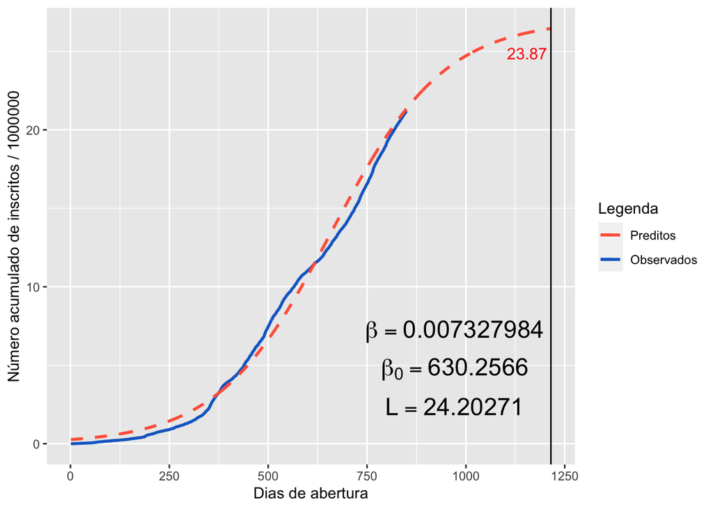

```r
# Populando o data frame e plotando os valores preditos:
params <- c(min_loss$fit_beta, min_loss$fit_beta0, min_loss$fit_L)
df_pred$fit <- f_log(par = params, dias = df_pred$DIAS)

df_pred %>%
  ggplot(aes(x = DIAS)) +
  geom_line(aes(y = cum_inscritos, color = "Observados"), size = 1) +
  geom_line(aes(y = adj, color = "Preditos"), linetype = "dashed", size = 1) +
  scale_color_manual(name = "Legenda", values = c("Preditos" = "tomato", "Observados" = "#166bcc")) +
  labs(x = "Dias de abertura", y = "Número acumulado de inscritos / 1000000") +
  geom_vline(xintercept = max(df_pred$DIAS), linetype = "solid", color = "black") +
  annotate("text", x = max(df_pred$DIAS)-60, y = max(df_pred$fit)+1, label = round(max(df_pred$fit),2), size = 4, color = "red") +
  annotate("text", x = max(df_pred$DIAS)*0.8, y = max(df_pred$fit)*0.1, label = paste0("L==",params[3]), size = 6, parse = T) +
  annotate("text", x = max(df_pred$DIAS)*0.8, y = max(df_pred$fit)*0.2, label = paste0("beta[0]==",params[2]), size = 6, parse = T) +
  annotate("text", x = max(df_pred$DIAS)*0.8, y = max(df_pred$fit)*0.3, label = paste0("beta==",params[1]), size = 6, parse = T)
```

Antes de utilizar o otimizador, foram realizados diversos testes com os parâmtros $\beta$, $\beta_0$ e $L$, variando manualmente a combinação deles e observando o comportamento da curva. Foi passada para o otimizador, como parâmetros iniciais, uma combinação que resultou em um comportamento semelhante ao da curva do número acumulado de inscritos. No entanto, foi observado que ao alterar, mesmo que sutilmente, os parâmetros iniciais, o otimizador apresentava resultados diferentes, então foi criado um grid de parâmetros, passada todas as combinações possíveis para o otimizador, armazenado os resultados em um data frame e calculada a perda quadrática em cada caso. Em seguida foi identificada a combinação dos parâmetros que resultou na menor perda quadrática e considerada esta combinação para realizar a predição.

De acordo com o modelo ajustado abaixo, em 365 dias o canal Invento na Hora terá obtido mais **267.099** inscritos, totalizando **2.387.388**, apresentando um crescimento de **12,6 %**.

$$y = \dfrac{24.20271}{1 +
e^{-0.007327984(x - 630.2566)}}$$